# 데이터 과학을 위한 저작도구: Computational Documents

R마크다운 보고서 패스워드 보안

이광춘

[Tidyverse Korea](https://www.facebook.com/groups/tidyverse/)

2021-01-02

# DevOps 파이프라인

보안이 강화된 웹페이지를 제작하기 위해서 패스워드로 보안이 되게 만들고, 당연히 R마크다운 코드 저장소도 Private GitHub Repository 를 제작하여 로컬 PC에서 개발되는 사항이 버전관리도 DevOps 기능도 되면서 보안도 패스워드 보안을 통해 작업이 되도록 준비한다.

[figure not shown]

# 1 GitHub 개인 저장소

GitHub에 개인 저장소를 제작한다. 제작된 클라우드 GitHub 저장소를 로컬 컴퓨터로 클론해서 R마크다운 작업을 수행한다.

[figure not shown]

# 2 GitHub 작업흐름

GitHub의 일반적인 작업 흐름에 맞춰 작업을 수행한다.

1. `git clone`
2. `git add`
3. `git commit -m`
4. `git push`

# 3 Netlify 저장소 등록

http://netlify.com/ 웹사이트에 Github Private 저장소를 등록시킨다. 필요한 경우 GitHub 저장소에도 NETLIFY APP ID와 NETLIFY_AUTH_TOKEN 을 등록시켜 상호간의 작업을 일원화 시킨다.

# 4 Netlify 비밀번호 등록

http://netlify.com/ 웹사이트에 배포한 앱에 대한 방문자 접근을 위해서 비밀번호 접근 권한 설정을 해야 된다. 매월 $19 달러 비용이 소요되니 주의하도록 한다.

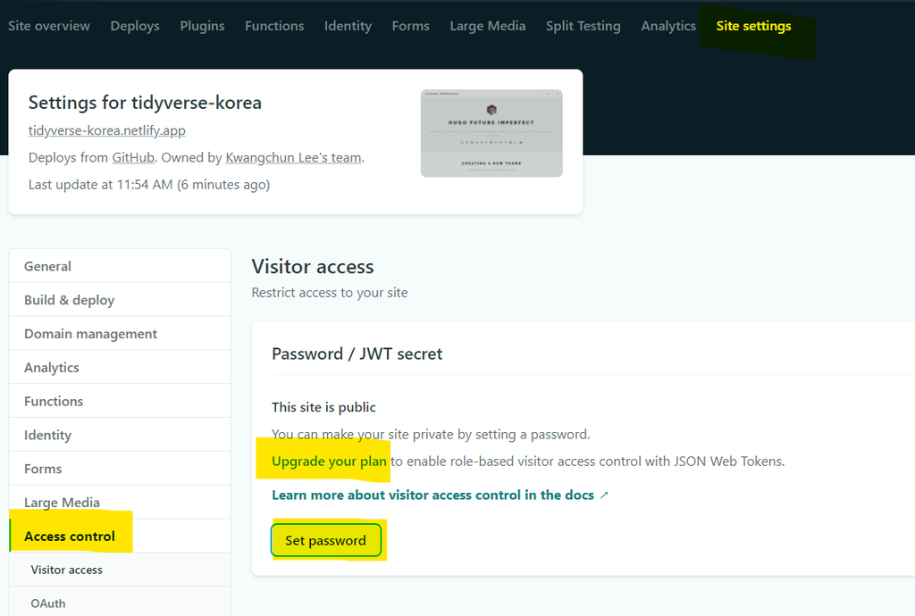

# 5 배포 웹사이트 비밀번호 적용

방문자 접근을 위해 비밀번호 설정이 완료된 경우 다음과 같이 비밀번호 보안기능이 활성화된 것을 확인할 수 있다.

[figure not shown]

데이터 과학자 [이광춘](https://github.com/statkclee/) 저작

*kwangchun.lee.7@gmail.com*